# Milestone Preliminary Report

Tops1752

Sunday, March 20, 2016

# Summary

This report is to disply and explain the exploratory analysis and the goals for the eventual app and algorithm, which inclludes:

– Data download

– Basic data summary

– Data exploratory analysis and interesting findings

– Next steps for prediction algorithm and shniy app

## Getting the Data

The corpora are collected from publicly available sources by a web crawler. The crawler checks for language, so as to mainly get texts consisting of the desired language. In this project, we are going to use en_US data, including sources from Twitter, Blogs and News. Download the data from Coursera site and set the direction to where the data is saved.

```r
## Read data
datTwitter <- readLines("final/en_US/en_US.twitter.txt")
datBlog <- readLines("final/en_US/en_US.blogs.txt")
datNews <- readLines("final/en_US/en_US.news.txt")
```

The table below shows a brief summary of the data:

| Data | Source | Size.MB | LineCount | WordCount |
| --- | --- | --- | --- | --- |
| datTwitter | final/en_US/en_US.twitter.txt | 159.3641 | 2360148 | 30373792 |
| datBlog | final/en_US/en_US.blogs.txt | 200.4242 | 899288 | 37334441 |
| datNews | final/en_US/en_US.news.txt | 196.2775 | 77259 | 2643972 |

## Data Cleaning

Use “tm” package to process and clean the data by transforming every word to lower case, removing punctuations and stripping out extra whitespace.

```r
library(tm)
text <- paste(datTwitter,datBlog,datNews, collapse = " ")
text.source <- VectorSource(text)

corpus <- Corpus(text.source)
corpus <- tm_map(corpus, content_transformer(tolower))
corpus <- tm_map(corpus, removePunctuation)
corpus <- tm_map(corpus, stripWhitespace)
```

## Data Exploratory

The first step is to review the instance and frequency of words.

```r
dtm <- DocumentTermMatrix(corpus)
dtm2 <- as.matrix(dtm)
frequency <- colSums(dtm2)
frequency <- sort(frequency, decreasing=TRUE)

dfFreq <- data.frame(words = names(frequency))
dfFreq$freq <- frequency
dfFreq$per <- frequency/sum(frequency)
dfFreq$cumsum <- cumsum(dfFreq$per)
dfFreq$wordPer <- 1/length(dfFreq$words)
dfFreq$cumWordPer <- cumsum(dfFreq$wordPer)
```

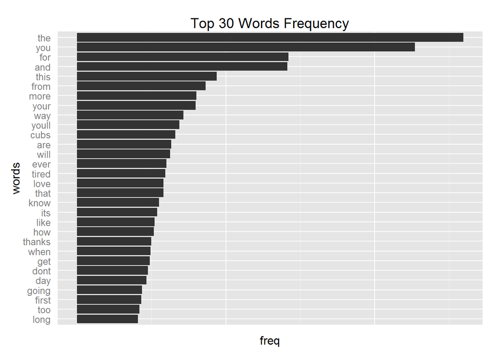

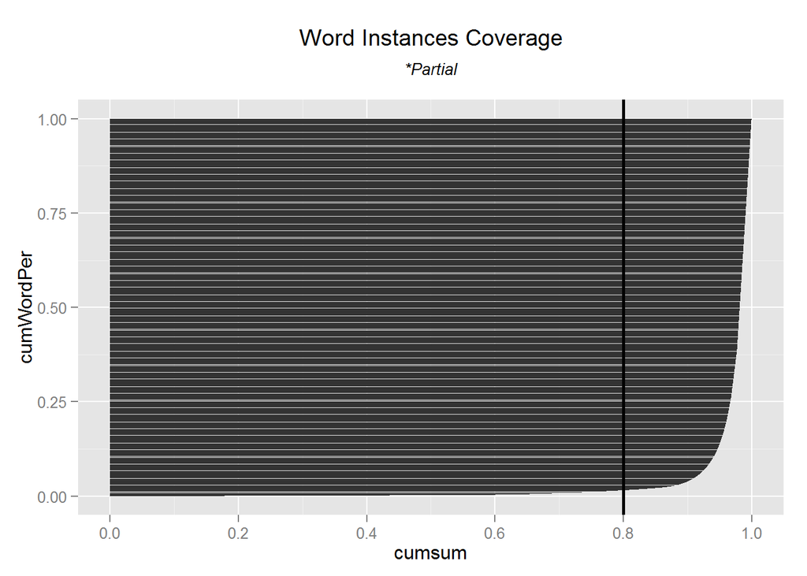

And the figure below is the wordcloud plot which gives a straightforward view on the word frequency.

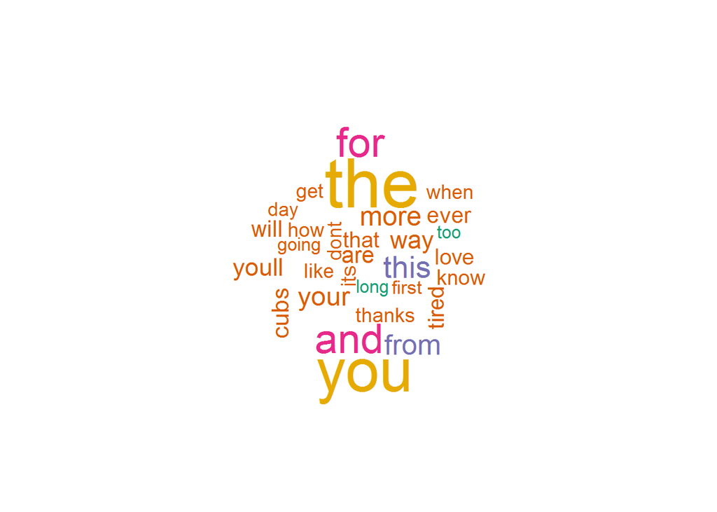

```r
library(wordcloud)
words <- names(frequency)
wordcloud(words[1:30], frequency[1:30],colors=brewer.pal(6, "Dark2"))
```

## Next Step

Next steps to develop the prediction algorithm and shiny app are:

– Generate the ngram model for prediction

– Model improvement by optimizing memory required and run time

– Model testing with test data

– Shiny app development